# Dominant Flows Analysis

Timothee Giraud

2015-03-24

## The method

Dominant Flows Analysis establishes a hierarchy between nodes. Used in geography it shows the influence of the distance and barrier effects on regionalisation.

## How to use the package

First case :  
`i` is dominated by `j` when:

- `i` sends its biggest flow to `j`
- `j` receives more flows than `i`

The flowDom function computes the dominant flows.

```r
library(flow)

data(LoireAtlantique)

dom1<- flowDom(mat = MRE44,
               i = "DCRAN",
               j = "CODGEO",
               fij = "NBFLUX_C08_POP05P")
```

The output of the fowDom function is a set of i j couples where i is dominated by j.

```r
head(dom1)
```

```
##       j     i       dom fij   sumInI   sumOutI sumInJ  sumOutJ
## 1 44003 44004 0.1919152  40 371.8974 208.42542   1088 1119.052
## 2 44003 44011 0.2611188  20 167.0902  76.59348   1088 1119.052
## 3 44003 44115 0.1546044  60 424.8559 388.08724   1088 1119.052
## 4 44003 44160 0.2841514 112 433.7223 394.15614   1088 1119.052
## 5 44003 44096 0.2509240 112 717.8295 446.35030   1088 1119.052
## 6 44003 44163 0.2488217  68 352.2708 273.28811   1088 1119.052
```

The next function plots the dominant flows on a map.

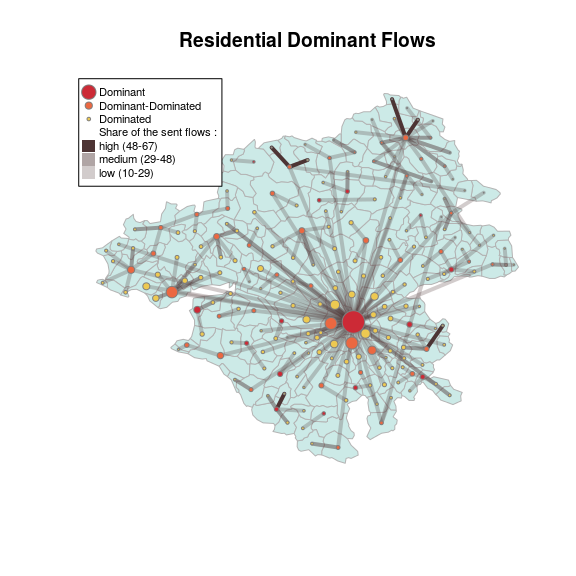

```r
plotflowDom(fdom = dom1, spdf = COM44, id = "INSEE_COM")
title("Residential Dominant Flows")
```

Second case :  
`i` is dominated by `j` when:

- `i` sends at least a share of its flows to `j`
- `j` receives more flows than `i`

Here, the k parameter sets the share of i outputed flows toward j.

```r
dom2 <- flowDom(mat = MRE44,
                i = "DCRAN",
                j = "CODGEO",
                fij = "NBFLUX_C08_POP05P",
                k = 0.2)
```

Then we plot the Map.

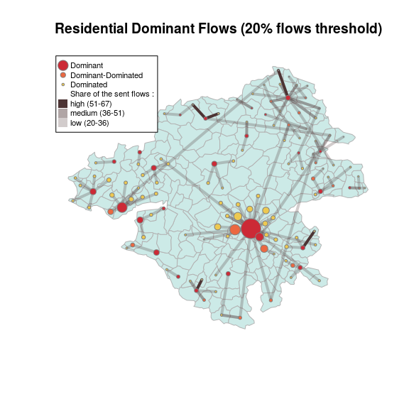

```r
plotflowDom(fdom = dom2, spdf = COM44, id = "INSEE_COM")
title("Residential Dominant Flows (20% flows threshold)")
```

It is also possible to add the names of dominant centers interactively by using the name parameter. Each click on a unit will display its name on the map. This function can only be used in an interactive environnement.